# Activity Monitoring Homework

Sunwoo

2017/12/18

## Loading and preprocessing the data

csv File에서 Data를 가져온다.

```r
activity<-read.csv("activity.csv")
head(activity)
```

```
##   steps       date interval
## 1    NA 2012-10-01        0
## 2    NA 2012-10-01        5
## 3    NA 2012-10-01       10
## 4    NA 2012-10-01       15
## 5    NA 2012-10-01       20
## 6    NA 2012-10-01       25
```

## What is mean total number of steps taken per day?

하루에 걸은 걸음 수의 합을 가진 Dataset을 만들고, 히스토그램으로 표현한다.

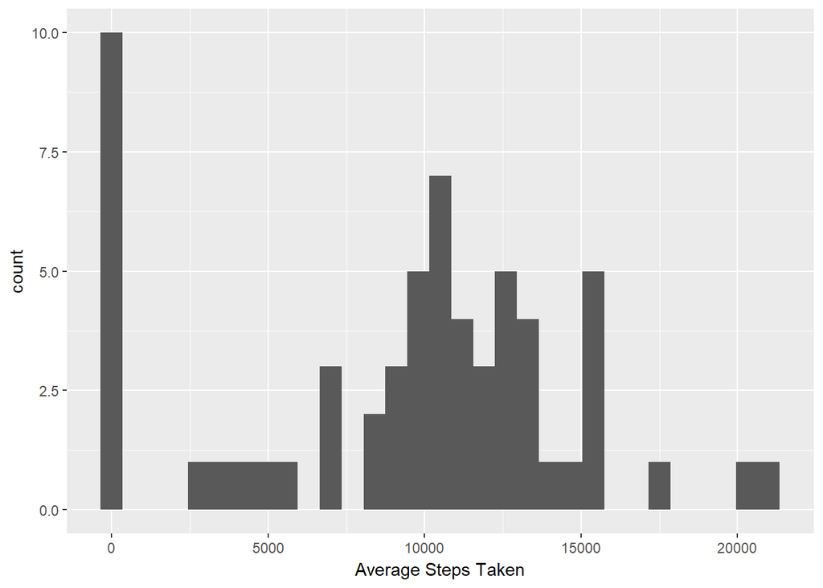

```r
activity_sum<-ddply(activity, .(date), summarize, agsteps = sum(steps, na.rm=T))
ggplot(activity_sum, aes(agsteps))+geom_histogram(na.rm=TRUE,binwidth=700)+xlab("Average Steps Taken")
```

```r
summary(activity_sum)
```

```
         date       agsteps
 2012-10-01: 1   Min.   :    0
 2012-10-02: 1   1st Qu.: 6778
 2012-10-03: 1   Median :10395
 2012-10-04: 1   Mean   : 9354
 2012-10-05: 1   3rd Qu.:12811
 2012-10-06: 1   Max.   :21194
 (Other)   :55
```

# What is the average daily activity pattern?

Interval 별 Average Steps를 가진 Dataset을 만들고, 시계열로 표현하였다.

Dataset에서 가장 많은 Steps를 가진 Interval은, which.max 함수로 알 수 있듯이 Interval 835였다. 해당 Interval의 Average Steps는 206.17로 나타났다.

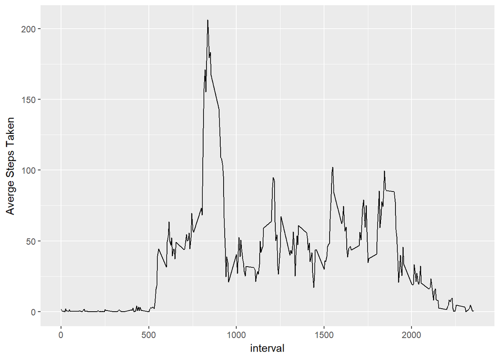

```r
activity_avg<-ddply(activity, .(interval), summarize, avsteps = mean(steps, na.rm=T))
ggplot(activity_avg, aes(x=interval, y=avsteps)) + geom_line()+xlab("interval")+ylab("Averge Steps Taken")
```

```r
summary(activity_avg)
```

```
##     interval         avsteps
##  Min.   :   0.0   Min.   :  0.000
##  1st Qu.: 588.8   1st Qu.:  2.486
##  Median :1177.5   Median : 34.113
##  Mean   :1177.5   Mean   : 37.383
##  3rd Qu.:1766.2   3rd Qu.: 52.835
##  Max.   :2355.0   Max.   :206.170
```

```r
activity_avg[which.max(activity_avg$avsteps),]
```

```
##     interval  avsteps
## 104      835 206.1698
```

# Imputing missing values

Count, is.na 함수로 결측치의 개수를 알 수 있었고, 2304개였다.

결측치를 보정한 데이터, 보정하지 않은 데이터의 평균과 중앙값을 비교하였다.

결측치를 보정한 경우는 평균과 중앙값이 모두 10766이었고, 보정하지 않은 경우는 평균은 9354, 중앙값은 10395 였다.

결측치를 보정했을 때 평균과 중앙값이 모두 높아졌고, 이는 결측치로 인해 0으로 계산되던 부분의 변화에서 나온 것으로 보인다.

히스토그램의 비교에서도 위와 같은 결과를 시각적으로 관찰할 수 있다.

```r
plyr::count(is.na(activity$steps))
```

```
##       x  freq
## 1 FALSE 15264
## 2  TRUE  2304
```

```r
activity_cor<-activity
avgsteps<-rep(activity_avg$avsteps, nrow(activity_sum))
activity_cor$steps<-ifelse(is.na(activity_cor$steps), avgsteps, activity_cor$steps)
head(activity_cor)
```

```
##       steps       date interval
## 1 1.7169811 2012-10-01        0
## 2 0.3396226 2012-10-01        5
## 3 0.1320755 2012-10-01       10
## 4 0.1509434 2012-10-01       15
## 5 0.0754717 2012-10-01       20
## 6 2.0943396 2012-10-01       25
```

```r
activity_cor_sum<-ddply(activity_cor, .(date), summarize, agsteps = sum(steps, na.rm=T))
summary(activity_cor_sum) # 결측치를 보정한 데이터의 평균과 중앙값
```

```
##          date       agsteps
##  2012-10-01: 1   Min.   :   41
##  2012-10-02: 1   1st Qu.: 9819
##  2012-10-03: 1   Median :10766
##  2012-10-04: 1   Mean   :10766
##  2012-10-05: 1   3rd Qu.:12811
##  2012-10-06: 1   Max.   :21194
##  (Other)   :55
```

```r
summary(activity_sum) #결측치를 보정하지 않은 데이터의 평균과 중앙값
```

```
##          date       agsteps
##  2012-10-01: 1   Min.   :    0
##  2012-10-02: 1   1st Qu.: 6778
##  2012-10-03: 1   Median :10395
##  2012-10-04: 1   Mean   : 9354
##  2012-10-05: 1   3rd Qu.:12811
##  2012-10-06: 1   Max.   :21194
##  (Other)   :55
```

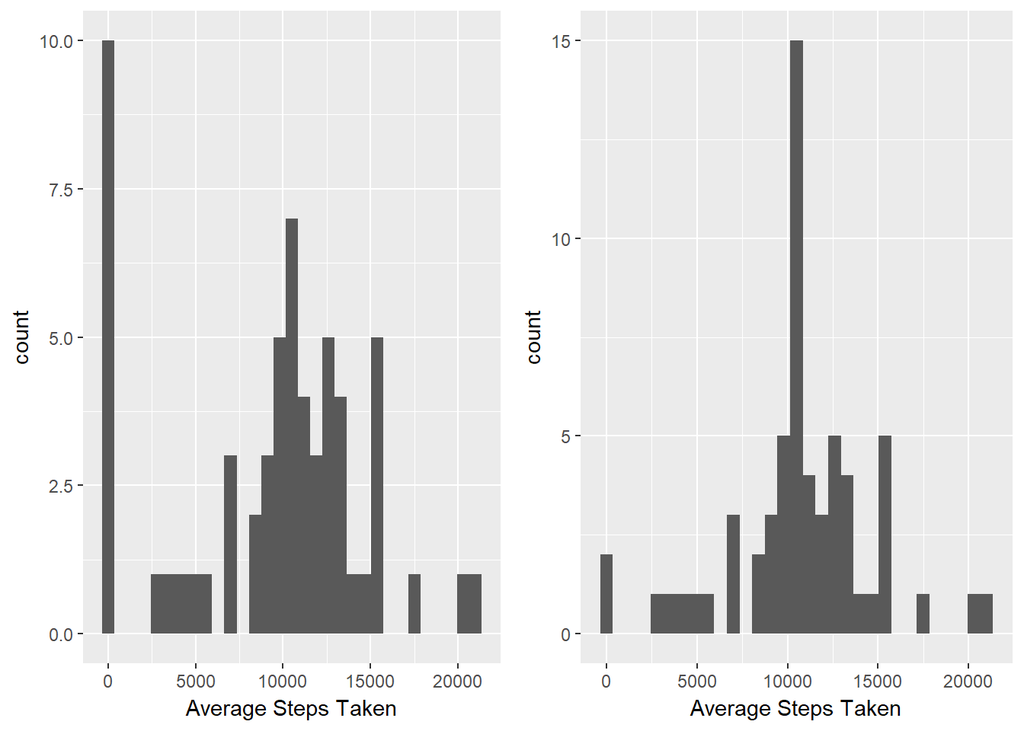

```r
p1=ggplot(activity_sum, aes(agsteps))+geom_histogram(na.rm=TRUE, binwidth=700)+xlab("Average Steps Taken")
p2=ggplot(activity_cor_sum, aes(agsteps))+geom_histogram(na.rm=TRUE, binwidth=700)+xlab("Average Steps Taken")
grid.arrange(p1, p2, ncol=2)
```

# Are there differences in activity patterns between weekdays and weekends?

주말과 평일로 나누어 생활 패턴을 비교하고, 각각 시계열로 표현하였다.

평일의 경우 주말보다 이른 시간에 걸음 수가 늘어나기 시작하였고, 약 8~9시경 최고치를 기록하였다. 이는 출근으로 인한 것으로 보인다. 또한 오후 7시경 다시 높은 수치를 기록한 것도 퇴근 때문으로 보인다. 그에 비해 주말의 경우 전반적으로 늦은 시간에 걸음 수가 증가하였고, 걸음 수의 편차도 평일보다 낮았다. 이는 주말이 평일보다 자유로운 스케줄을 갖는 데서 기인한 것으로 보인다.

```r
activity_week<-activity_cor
activity_week$date<-as.Date(activity_week$date) #Weekdays 함수를 활용하기 위함
activity_week$week<-weekdays(activity_week$date)
activity_week$weekend <- ifelse(activity_week$week == "토요일" | activity_week$week == "일요일", "weekend","weekday")
activity_week_avg<-ddply(activity_week, .(interval, weekend), summarize, avsteps = mean(steps, na.rm=T))
# 각 Interval 별 평균 걸음 수를 계산하되, 주말과 평일을 분류함.
head(activity_week_avg)
```

```
##   interval weekend    avsteps
## 1        0 weekday 2.25115304
## 2        0 weekend 0.21462264
## 3        5 weekday 0.44528302
## 4        5 weekend 0.04245283
## 5       10 weekday 0.17316562
## 6       10 weekend 0.01650943
```

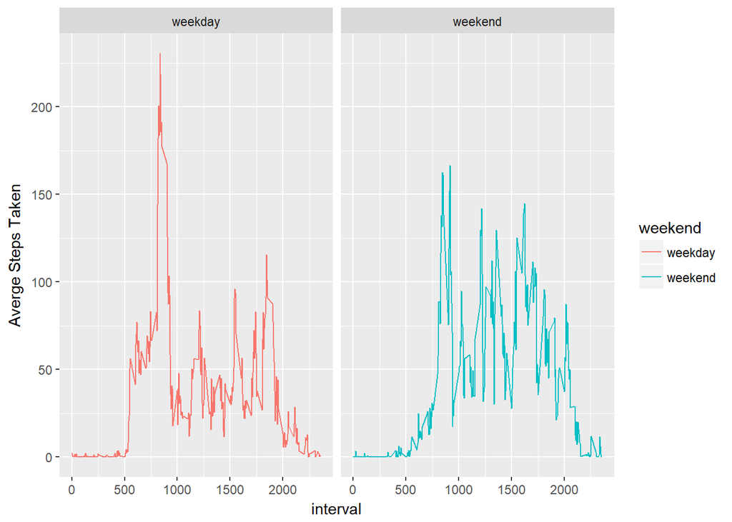

```r
ggplot(activity_week_avg, aes(color=weekend, x=interval, y=avsteps)) + geom_line()+xlab("interval")+ylab("Averge Steps Taken")+facet_grid( . ~ weekend)
```